# Notebook

## Preparation

```python
%matplotlib inline
import matplotlib.pyplot as plt
import numpy as np
import scipy.stats
from statsmodels.distributions.empirical_distribution import ECDF

def read_keystrokes(keystroke_filename):
    keystrokes = []
    with open(keystroke_filename) as keystroke_file:
        for line in keystroke_file.readlines():
            record = line.strip().split()
            timestamp = float(record[0])
            user = record[1]
            keystrokes.append((timestamp, user))
    return keystrokes
```

```python
keystrokes = read_keystrokes("keystroke-timing.txt")
```

### 1. Summarize the most basic properties of the dataset. (I'm leaving this vague so you can reflect on just what constitutes those basic properties.)

The basic properties we examine are:

- number of events,
- number of users,
- ordering of events,
- ordering of users,
- time duration,
- distribution of all events over time,
- distribution of each user's events over time,
- distribution of the number of events per user,
- user arrival distribution,
- number of events and arrival times of the most and least prolific (in terms of number of events) users, and
- rate of event arrival per user.

The number of events are:

```python
len(keystrokes)
```

```
74883
```

The number of users are:

```python
len(set([user for (timestamp, user) in keystrokes]))
```

```
250
```

The events are sorted by time:

```python
sorted_keystrokes = sorted(keystrokes)
sorted_keystrokes == keystrokes
```

```
True
```

The data set spans a duration of about an hour:

```python
first_timestamp = keystrokes[0][0]
last_timestamp = keystrokes[-1][0]
duration_in_secs = last_timestamp - first_timestamp
print duration_in_secs
```

```
3606.79002285
```

```python
duration_in_mins = duration_in_secs/60.
print duration_in_mins
```

```
60.1131670475
```

The distribution of events over time does not look unusual or that notable:

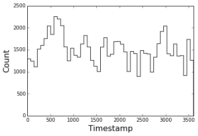

```python
first_arrival = keystrokes[0][0]
num_bins = 50
timestamps = [record[0] - first_timestamp for record in keystrokes]
plt.ylim(ymin=0, ymax=2500) # Necessary due to bug for histtype='step' below.
n, bins, patches = plt.hist(timestamps, num_bins, histtype='step', color='black')
plt.xlabel("Timestamp", fontsize=16)
plt.xlim(xmin=0, xmax=duration_in_secs)
_ = plt.ylabel("Count", fontsize=16)
```

We'll examine the distribution of events per user to see if there are any unusual users.

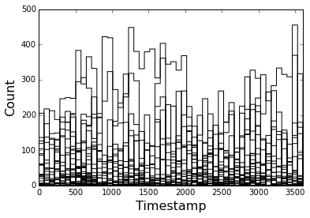

```python
keystrokes_by_user = { user: [] for (timestamp, user) in keystrokes}
for (timestamp, user) in keystrokes:
    keystrokes_by_user[user].append(timestamp)
keystrokes_by_user = { user: sorted(timestamps) for (user, timestamps) in keystrokes_by_user.iteritems()}
plt.ylim(ymin=0, ymax=500) # Necessary due to bug for histtype='step' below.
plt.ylabel("Count", fontsize=16)
for (user, timestamps) in keystrokes_by_user.iteritems():
    timestamps_zero = [t-first_arrival for t in timestamps]
    plt.hist(timestamps_zero, bins=num_bins, range=(0, int(np.ceil(duration_in_secs))), histtype='step', color='black')
plt.xlabel("Timestamp", fontsize=16)
_ = plt.xlim(xmin=0, xmax=duration_in_secs)
```

The above graph doesn't reveal much, so let's try to look a few different ways.

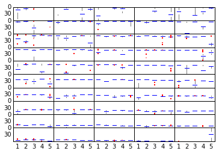

```python
keystrokes_sorted_by_user = sorted(keystrokes_by_user.iteritems(), key=lambda x: int(x[0][4:]))
keystrokes_sorted = [tup[1] for tup in keystrokes_sorted_by_user]
for idx, timestamps in enumerate(keystrokes_sorted):
    keystrokes_sorted[idx] = [(t - first_timestamp)/60. for t in timestamps]

def plot_boxplot_per_user(seqs):
    nrows = 10
    ncols = 5
    f, subf = plt.subplots(nrows, ncols)
    row = 0
    col = 0
    flierprops = dict(marker='o', markeredgecolor='red', markersize=1)
    medianprops = dict(linestyle='-', color='blue')
    whiskerprops = dict(linestyle='-', color='gray')
    for idx in range(0, len(seqs), 5):
        to_plot = seqs[idx:idx+5]
        subf[row, col].boxplot(to_plot, showbox=False, showcaps=False, sym='o',
                               medianprops=medianprops,
                               whiskerprops=whiskerprops,
                               flierprops=flierprops)
        subf[row, col].set_ylim(ymin=0, ymax=60)
        subf[row, col].invert_yaxis()
        if row != (nrows - 1):
            subf[row, col].set_xticks([])
        else:
            subf[row, col].tick_params(axis='x', which='both', bottom='off', top='off')
            subf[row, col].set_xticks(range(1,6))
        if col != 0:
            subf[row, col].set_yticks([])
        else:
            subf[row, col].tick_params(axis='y', which='both', left='off', right='off')
            subf[row, col].set_yticks([0, 30])
        col += 1
        if col == ncols:
            col = 0
            row += 1
    f.subplots_adjust(hspace=0, wspace=0)

plot_boxplot_per_user(keystrokes_sorted)
```

This is interesting, but it makes me wonder if I should have ordered the users by arrival time instead of by label. Let's see what happens when we do that:

```python
keystrokes_sorted_by_user = sorted(keystrokes_by_user.iteritems(), key=lambda x: int(x[0][4:]))
keystrokes_sorted_by_arrival = sorted(keystrokes_by_user.iteritems(), key=lambda x: x[1][0])
users_by_name = [t[0] for t in keystrokes_sorted_by_user]
users_by_arrival = [t[0] for t in keystrokes_sorted_by_arrival]
user_order_matches_arrival = users_by_name == users_by_arrival
print "User number order matches arrival order: %s" % user_order_matches_arrival
nidx = aidx = 0
nusers = len(users_by_name)
print "Out of order users:",
ooo = []
while nidx < nusers - 1 and aidx < nusers - 1:
    n = users_by_name[nidx]
    a = users_by_arrival[aidx]
    if n == a:
        aidx += 1
        nidx += 1
    else:
        print a,
        ooo.append(a)
        aidx += 1

print
for user in ooo:
    print "%s keystrokes:" % user
    print [(t - first_timestamp)/60. for t in keystrokes_by_user[user]]
```

```
User number order matches arrival order: False
Out of order users: user250
user250 keystrokes:
[0.014003129800160725, 1.0065730492273965, 2.0130516489346824, 3.0133073329925537, 4.015194114049276, 5.003292512893677, 6.005587049325308, 7.012803832689921, 8.00462958017985, 9.009232831001281, 10.007956616083781, 11.010481182734171, 12.006079749266307, 13.008556679884594, 14.015870499610902, 15.0…
```

Ah ha! There is a bogus user. Let's see if we can spot any others easily.

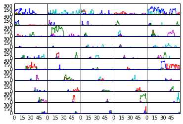

```python
def plot_hist_per_user(seqs):
    nrows = 10
    ncols = 5
    f, subf = plt.subplots(nrows, ncols)
    row = 0
    col = 0
    for idx in range(0, len(seqs), 5):
        to_plot = seqs[idx:idx+5]
        subf[row, col].hist(to_plot, bins=60,
                            range=(0, int(np.ceil(duration_in_mins))), histtype='step')
        subf[row, col].set_ylim(ymin=0, ymax=400)
        subf[row, col].set_xlim(xmin=0, xmax=int(np.ceil(duration_in_mins)))
        if row != (nrows - 1):
            subf[row, col].set_xticks([])
        else:
            subf[row, col].tick_params(axis='x', which='both', bottom='off', top='off')
            subf[row, col].set_xticks([0, 15, 30, 45])
        if col != 0:
            subf[row, col].set_yticks([])
        else:
            subf[row, col].tick_params(axis='y', which='both', left='off', right='off')
            subf[row, col].set_yticks([0, 150, 300])
        col += 1
        if col == ncols:
            col = 0
            row += 1
    f.subplots_adjust(hspace=0, wspace=0)

plot_hist_per_user(keystrokes_sorted)
```

Well, this doesn't reveal much because the suspicious user has a low level of activity. So you can't detect it from the above graph, nor see if there are others.

Let's next see what the number of events per users tells us:

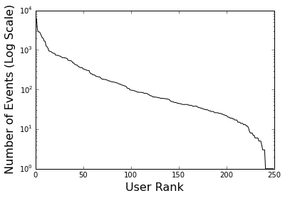

```python
events_per_user = [(user, len(events)) for (user, events) in keystrokes_by_user.iteritems()]
events_per_user = sorted(events_per_user, key=lambda x: x[1], reverse=True)
users, num_events = zip(*events_per_user)
plt.plot(num_events, color='black')
plt.xlabel("User Rank", fontsize=16)
plt.yscale('log')
_ = plt.ylabel("Number of Events (Log Scale)", fontsize=16)
```

There are some users with a lot more events than others -- is this due to their arrival times? I am guessing so based on the above distributions. But let's look closer at their arrival times:

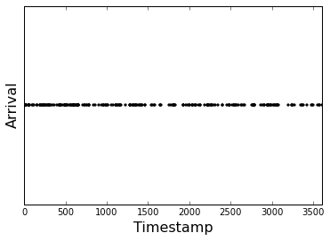

```python
user_arrivals = [(user, timestamps[0]) for (user, timestamps) in keystrokes_by_user.iteritems()]
user_arrivals = sorted(user_arrivals, key=lambda x: x[1])
arrival_times = [timestamp-first_timestamp for (user, timestamp) in user_arrivals]
plt.xlabel("Timestamp", fontsize=16)
plt.xlim(xmin=0, xmax=duration_in_secs)
plt.ylabel("Arrival", fontsize=16)
plt.yticks([])
_ = plt.scatter(arrival_times, [1]*len(arrival_times), s=5, color='black')
```

It's hard to tell much from this. Let's look at the arrival times of the most prolific and least prolific users specifically:

```python
N = 50
ncols = 2
spaces = 24
print "Top %d users, rank, number of events, and arrival time (minutes):" % N
user_width = max([len(user) for user in users])
rows = [[] for _ in range(N/ncols)]
topN_by_nevents = users[:N]
for idx, user in enumerate(topN_by_nevents):
    rank = idx + 1
    user_label = user.ljust(user_width)
    nevents = num_events[idx]
    arrival = (keystrokes_by_user[user][0] - first_arrival)/60.
    arrival = "({:4.1f})".format(arrival)
    ranked_user = "%2d. %s (%4d) %s" % (rank, user_label, nevents, arrival)
    rows[idx % len(rows)].append(ranked_user)
for row in rows:
    print "".join(user.ljust(user_width + spaces) for user in row)
```

```
Top 50 users, rank, number of events, and arrival time (minutes):
 1. user21  (6918) ( 0.3)      26. user60  ( 706) ( 7.3)
 2. user57  (6063) ( 6.9)      27. user20  ( 690) ( 0.3)
 3. user1   (3151) ( 0.0)      28. user114 ( 669) (18.0)
 4. user9   (2856) ( 0.1)      29. user73  ( 642) ( 9.0)
 5. user148 (2855) (27.4)      30. user197 ( 640) (42.8)
 6. user217 (2629) (49.0)      31. user183 ( 634) (37.9)
 7. user146 (2323) (26.4)      32. user72  ( 629) ( 8.6)
 8. user128 (2030) (21.5)      33. user52  ( 619) ( 5.1)
 9. user24  (1978) ( 0.4)      34. user193 ( 611) (42.0)
10. user14  (1678) ( 0.1)      35. user202 ( 550) (44.3)
11. user75  (1657) ( 9.3)      36. user107 ( 546) (16.0)
12. user157 (1263) (30.5)      37. user89  ( 534) (10.8)
13. user99  (1203) (13.0)      38. user155 ( 533) (30.3)
14. user13  (1105) ( 0.1)      39. user42  ( 522) ( 3.8)
15. user104 ( 939) (15.1)      40. user36  ( 471) ( 3.2)
16. user26  ( 929) ( 0.8)      41. user164 ( 471) (33.3)
17. user108 ( 912) (16.0)      42. user243 ( 436) (57.9)
18. user208 ( 876) (46.3)      43. user127 ( 424) (21.3)
19. user224 ( 835) (49.9)      44. user125 ( 417) (21.2)
20. user18  ( 829) ( 0.2)      45. user23  ( 406) ( 0.4)
21. user205 ( 820) (46.1)      46. user47  ( 377) ( 4.5)
22. user69  ( 738) ( 8.3)      47. user28  ( 373) ( 0.9)
23. user122 ( 734) (19.4)      48. user31  ( 358) ( 1.5)
24. user11  ( 734) ( 0.1)      49. user62  ( 358) ( 7.4)
25. user158 ( 721) (32.0)      50. user3   ( 356) ( 0.0)
```

```python
print "Bottom %d users, rank, number of events, and arrival time (minutes):" % N
user_width = max([len(user) for user in users])
rows = [[] for _ in range(N/ncols)]
bottomN_by_nevents = users[-N:]
for idx, user in enumerate(bottomN_by_nevents):
    idx = len(users) - N + idx
    rank = idx + 1
    user_label = user.ljust(user_width)
    nevents = num_events[idx]
    arrival = (keystrokes_by_user[user][0] - first_arrival)/60.
    arrival = "({:4.1f})".format(arrival)
    ranked_user = "%2d. %s (%4d) %s" % (rank, user_label, nevents, arrival)
    rows[idx % len(rows)].append(ranked_user)
for row in rows:
    print "".join(user.ljust(user_width + spaces) for user in row)
```

```
Bottom 50 users, rank, number of events, and arrival time (minutes):
201. user77  (  22) ( 9.7)     226. user129 (   8) (21.9)
202. user81  (  21) (10.1)     227. user30  (   8) ( 1.1)
203. user168 (  20) (34.5)     228. user211 (   8) (46.5)
204. user142 (  20) (24.4)     229. user39  (   7) ( 3.5)
205. user80  (  19) (10.1)     230. user67  (   7) ( 8.3)
206. user140 (  19) (23.9)     231. user249 (   6) (60.1)
207. user216 (  19) (48.5)     232. user44  (   6) ( 4.0)
208. user96  (  18) (12.2)     233. user12  (   6) ( 0.1)
209. user84  (  18) (10.2)     234. user139 (   6) (23.7)
210. user55  (  17) ( 6.1)     235. user33  (   5) ( 2.0)
211. user194 (  17) (42.3)     236. user234 (   5) (53.9)
212. user178 (  17) (37.1)     237. user223 (   5) (49.8)
213. user141 (  15) (24.4)     238. user5   (   4) ( 0.0)
214. user219 (  15) (49.2)     239. user222 (   3) (49.8)
215. user218 (  15) (49.1)     240. user16  (   3) ( 0.2)
216. user233 (  14) (53.3)     241. user160 (   3) (32.1)
217. user91  (  14) (10.9)     242. user41  (   1) ( 3.7)
218. user161 (  14) (32.7)     243. user159 (   1) (32.1)
219. user147 (  13) (27.4)     244. user242 (   1) (57.1)
220. user106 (  13) (15.9)     245. user248 (   1) (59.6)
221. user239 (  13) (56.0)     246. user121 (   1) (19.3)
222. user126 (  12) (21.3)     247. user37  (   1) ( 3.2)
223. user186 (  12) (39.1)     248. user22  (   1) ( 0.3)
224. user152 (  11) (30.0)     249. user15  (   1) ( 0.2)
225. user34  (   9) ( 2.5)     250. user17  (   1) ( 0.2)
```

Some of the users with the most events showed up late and some with the least showed up early, indicating a lot of variation in the level of activity. Let's see if we can see this reflected in the event rate per user:

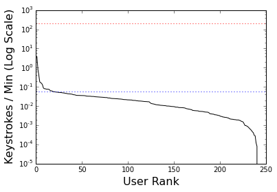

```python
keyrate_by_user = [(user, len(timestamps)/(timestamps[-1] - timestamps[0])
                                     if timestamps[0] < timestamps[-1] else 0.)
                                     for (user, timestamps) in keystrokes_by_user.iteritems()]
keyrate_by_user = sorted(keyrate_by_user, key=lambda x: x[1], reverse=True)
users, rate = zip(*keyrate_by_user)
keyrates_per_min = [r/60. for r in rate]
plt.plot(keyrates_per_min, color='black')
plt.xlabel("User Rank", fontsize=16)
plt.yscale('log')
plt.ylabel("Keystrokes / Min (Log Scale)", fontsize=16)
avg_word_length = 5 # Word length in English according to Wolfram Alpha.
avg_words_per_min = 40 # WPM according to Google.
expected_keyrate_per_min = avg_words_per_min * avg_word_length
plt.axhline(expected_keyrate_per_min, color='red', linestyle=':')
_ = plt.axhline(np.mean(keyrates_per_min), linestyle=':')
```